[GitHub](https://github.com/agate-model/Agate.jl)[](https://github.com/agate-model/Agate.jl/blob/main/examples/forwarddiff_nipizd_ode.jl)

# Forward-mode AD sensitivity

In this example we use ForwardDiff.jl to compute the sensitivity of phytoplankton 1 (P1) in an N2P2ZD model to P1's maximum growth rate parameter.

## Loading dependencies

The example uses Agate.jl for the ecosystem model, OrdinaryDiffEq.jl for a small standalone ODE solve, ForwardDiff.jl for the derivative, and CairoMakie.jl for plotting.

```julia
using Agate
using ForwardDiff
using OrdinaryDiffEq: ODEProblem, Tsit5, solve
using CairoMakie
using Printf

using Oceananigans.Biogeochemistry: required_biogeochemical_tracers
using Oceananigans.Units: day

const NiPiZD = Agate.Models.NiPiZD
const TRACERS = (:N, :D, :Z1, :Z2, :P1, :P2)
```

## Constructing an ForwardDiff.jl compatible model

Agate.jl uses an explicit constructor-boundary scalar type contract. For ordinary Oceananigans.jl simulations this scalar type comes from the grid, or defaults to `Float64`. For ForwardDiff.jl, we pass the active scalar type explicitly with `scalar_type = typeof(mu)`.

```julia
function nipizd_model_with_p1_growth_rate(mu)
    T = typeof(mu)

    return NiPiZD.construct(;
        scalar_type=T,
        parameters=(; maximum_growth_rate=(P1=mu, P2=T(0.7 / day))),
    )
end
```

Here `mu` is the maximum growth rate of `P1`. The `P2` growth rate is held fixed, and omitted zooplankton entries are filled from defaults.

## Standalone ODE problem

We define a small standalone ODE that calls Agate.jl's generated biological tendency functions directly.

```julia
function initial_conditions(::Type{T}) where {T}
    return T[7.0, 1.0, 0.05, 0.05, 0.01, 0.01]
end

constant_PAR(::Type{T}) where {T} = T(100.0)

function solve_nipizd(mu; saveat=range(0.0, 365day; length=366))
    T = typeof(mu)
    bgc = nipizd_model_with_p1_growth_rate(mu)

    required_biogeochemical_tracers(bgc) == TRACERS ||
        error("Unexpected NiPiZD tracer order: $(required_biogeochemical_tracers(bgc))")

    function rhs!(du, u, _, t)
        PAR = constant_PAR(T)
        for (i, tracer) in enumerate(TRACERS)
            du[i] = bgc(Val(tracer), 0, 0, 0, t, u..., PAR)
        end
        return nothing
    end

    u0 = initial_conditions(T)
    problem = ODEProblem(rhs!, u0, (first(saveat), last(saveat)))
    return solve(problem, Tsit5(); saveat=saveat, abstol=1e-10, reltol=1e-10)
end
```

We expose the `P1` trajectory (e.g. biomass values over time) as a vector-valued function of one parameter. This is the function that ForwardDiff.jl differentiates.

```julia
function p1_trajectory(theta; saveat=range(0.0, 365day; length=366))
    sol = solve_nipizd(theta[1]; saveat=saveat)
    values = reduce(hcat, sol.u)
    return vec(values[5, :])
end

function p1_solution(mu; saveat=range(0.0, 365day; length=366))
    sol = solve_nipizd(mu; saveat=saveat)
    values = reduce(hcat, sol.u)
    return vec(values[5, :])
end
```

## ForwardDiff.jl and finite differences

We compute the time-dependent sensitivity of `P1` to its own maximum growth rate. A central finite difference provides a simple independent check.

```julia
function finite_difference_p1_trajectory(mu0, delta; saveat)
    plus = p1_trajectory([mu0 + delta]; saveat=saveat)
    minus = p1_trajectory([mu0 - delta]; saveat=saveat)
    return (plus .- minus) ./ (2delta)
end

saveat = collect(range(0.0, 365day; length=366))
mu0 = 0.7 / day
delta = mu0 * 1e-6

baseline = p1_solution(mu0; saveat=saveat)
J = ForwardDiff.jacobian(theta -> p1_trajectory(theta; saveat=saveat), [mu0])
forwarddiff_sensitivity = J[:, 1]
finite_difference_sensitivity = finite_difference_p1_trajectory(mu0, delta; saveat=saveat)

@printf("Final dP1/dmu, ForwardDiff:       %.8e\n", forwarddiff_sensitivity[end])
@printf("Final dP1/dmu, finite difference: %.8e\n", finite_difference_sensitivity[end])
@printf(
    "Maximum absolute sensitivity difference: %.8e\n",
    maximum(abs.(forwarddiff_sensitivity .- finite_difference_sensitivity)),
)
```

```
Final dP1/dmu, ForwardDiff:       -1.04463612e+05
Final dP1/dmu, finite difference: -1.04463612e+05
Maximum absolute sensitivity difference: 1.15653449e+00
```

## Plotting

The top panel shows P1 biomass over time. The bottom panel compares the ForwardDiff.jl sensitivity with the central finite difference estimate.

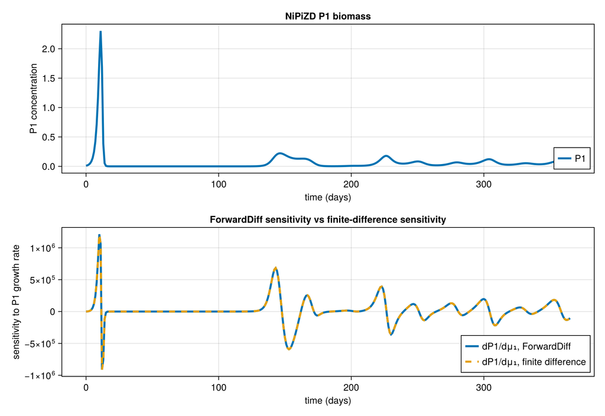

```julia
time_days = saveat ./ day
fig = Figure(; size=(900, 620), fontsize=14)

ax1 = Axis(
    fig[1, 1]; xlabel="time (days)", ylabel="P1 concentration", title="NiPiZD P1 biomass"
)
lines!(ax1, time_days, baseline; label="P1", linewidth=3)
axislegend(ax1; position=:rb)

ax2 = Axis(
    fig[2, 1];
    xlabel="time (days)",
    ylabel="sensitivity to P1 growth rate",
    title="ForwardDiff sensitivity vs finite-difference sensitivity",
)
lines!(ax2, time_days, forwarddiff_sensitivity; label="dP1/dμ₁, ForwardDiff", linewidth=3)
lines!(
    ax2,
    time_days,
    finite_difference_sensitivity;
    linestyle=:dash,
    label="dP1/dμ₁, finite difference",
    linewidth=3,
)
axislegend(ax2; position=:rb)

output_path = joinpath(@__DIR__, "forwarddiff_nipizd_ode_sensitivity.png")
save(output_path, fig)

fig
```

*This page was generated using Literate.jl.*